# Ноутбук для семинара `Трекинг экспериментов`

Сегодня мы:

- рассмотрим пайплайн подготовки данных и обучения модели классификации доходов
- создадим эксперимент в MLflow и настроим логирование:
  - параметров
  - метрик
  - моделей
  - артефактов
- проведём серию запусков с изменением параметров и сравним результаты в UI MLflow

```python
!pip install numpy datasets scikit-learn mlflow==2.20.2
```

```python
!pip install catboost -q
```

```
   ━━━━━━━━━━━━━━━━━━━━━━━━━━━━━━━━━━━━━━━━ 97.1/97.1 MB 6.7 MB/s eta 0:00:00
```

## Импорты

```python
# импорты для пайплайна

import numpy as np
from datasets import load_dataset
from sklearn.compose import ColumnTransformer
from sklearn.linear_model import LogisticRegression
from sklearn.metrics import accuracy_score, f1_score, roc_auc_score, precision_score, recall_score, precision_recall_curve, auc
from sklearn.model_selection import train_test_split
from sklearn.pipeline import Pipeline
from sklearn.preprocessing import OrdinalEncoder, StandardScaler, OneHotEncoder, TargetEncoder
import matplotlib.pyplot as plt
import sklearn
import random

import mlflow
from catboost import CatBoostClassifier
```

```python
dir(sklearn.preprocessing)
```

[output not shown]

```python
mlflow.set_tracking_uri('http://158.160.242.172:5000/')
```

```python
mlflow.set_experiment(experiment_id='12')
```

```
<Experiment: artifact_location='mlflow-artifacts:/12', creation_time=1776687378477, experiment_id='12', last_update_time=1776687378477, lifecycle_stage='active', name='homework-eazharikov.ext', tags={}>
```

### Константы

```python
DATASET_NAME = 'scikit-learn/adult-census-income'
TEST_SIZE = 0.2
RANDOM_STATE = 42
```

```python
random.seed(RANDOM_STATE)
np.random.seed(RANDOM_STATE)
```

## Скачивание и подготовка данных

Скачаем данные

```python
dataset = load_dataset(DATASET_NAME)
```

Посмотрим на них и изучим

```python
dataset
```

```
DatasetDict({
    train: Dataset({
        features: ['age', 'workclass', 'fnlwgt', 'education', 'education.num', 'marital.status', 'occupation', 'relationship', 'race', 'sex', 'capital.gain', 'capital.loss', 'hours.per.week', 'native.country', 'income'],
        num_rows: 32561
    })
})
```

```python
dataset['train'].features
```

```
{'age': Value('int64'),
 'workclass': Value('string'),
 'fnlwgt': Value('int64'),
 'education': Value('string'),
 'education.num': Value('int64'),
 'marital.status': Value('string'),
 'occupation': Value('string'),
 'relationship': Value('string'),
 'race': Value('string'),
 'sex': Value('string'),
 'capital.gain': Value('int64'),
 'capital.loss': Value('int64'),
 'hours.per.week': Value('int64'),
 'native.country': Value('string'),
 'income': Value('string')}
```

```python
df = dataset['train'].to_pandas()
df
```

|  | age | workclass | fnlwgt | education | education.num | marital.status | occupation | relationship | race | sex | capital.gain | capital.loss | hours.per.week | native.country | income |
| --- | --- | --- | --- | --- | --- | --- | --- | --- | --- | --- | --- | --- | --- | --- | --- |
| 0 | 90 | ? | 77053 | HS-grad | 9 | Widowed | ? | Not-in-family | White | Female | 0 | 4356 | 40 | United-States | <=50K |
| 1 | 82 | Private | 132870 | HS-grad | 9 | Widowed | Exec-managerial | Not-in-family | White | Female | 0 | 4356 | 18 | United-States | <=50K |
| 2 | 66 | ? | 186061 | Some-college | 10 | Widowed | ? | Unmarried | Black | Female | 0 | 4356 | 40 | United-States | <=50K |
| 3 | 54 | Private | 140359 | 7th-8th | 4 | Divorced | Machine-op-inspct | Unmarried | White | Female | 0 | 3900 | 40 | United-States | <=50K |
| 4 | 41 | Private | 264663 | Some-college | 10 | Separated | Prof-specialty | Own-child | White | Female | 0 | 3900 | 40 | United-States | <=50K |
| ... | ... | ... | ... | ... | ... | ... | ... | ... | ... | ... | ... | ... | ... | ... | ... |
| 32556 | 22 | Private | 310152 | Some-college | 10 | Never-married | Protective-serv | Not-in-family | White | Male | 0 | 0 | 40 | United-States | <=50K |
| 32557 | 27 | Private | 257302 | Assoc-acdm | 12 | Married-civ-spouse | Tech-support | Wife | White | Female | 0 | 0 | 38 | United-States | <=50K |
| 32558 | 40 | Private | 154374 | HS-grad | 9 | Married-civ-spouse | Machine-op-inspct | Husband | White | Male | 0 | 0 | 40 | United-States | >50K |
| 32559 | 58 | Private | 151910 | HS-grad | 9 | Widowed | Adm-clerical | Unmarried | White | Female | 0 | 0 | 40 | United-States | <=50K |
| 32560 | 22 | Private | 201490 | HS-grad | 9 | Never-married | Adm-clerical | Own-child | White | Male | 0 | 0 | 20 | United-States | <=50K |

32561 rows × 15 columns

Описание признаков:

- `age` — возраст человека
- `workclass` — тип занятости
- `fnlwgt` — вес наблюдения в данных переписи населения США (сколько реальных людей в популяции «представляет» эта строка)
- `education` — образование
- `education.num` — уровень образования в виде числа
- `marital.status` — семейное положение
- `occupation` — профессия / род деятельности
- `relationship` — роль человека в семье
- `race` — расовая группа
- `sex` — пол человека (`Male` / `Female`)
- `capital.gain` — доход от капитала (прибыль от продажи активов)
- `capital.loss` — убытки от капитала
- `hours.per.week` — количество рабочих часов в неделю
- `native.country` — страна происхождения

Описание таргета:

- `income` — бинарно, получает человек больше 50k $ в год или нет

Оставим только часть признаков

```python
columns = [
    'age', 'workclass', 'education.num', 'occupation', 'marital.status',
    'capital.gain', 'hours.per.week', 'sex',
    'capital.loss', 'native.country', 'race'
]

target_column = 'income'
```

И разделим датафрейм на признаки и таргет

```python
X, y = df[columns], df[target_column]
```

```python
X
```

|  | age | workclass | education.num | occupation | marital.status | capital.gain | hours.per.week | sex | capital.loss | native.country | race |
| --- | --- | --- | --- | --- | --- | --- | --- | --- | --- | --- | --- |
| 0 | 90 | ? | 9 | ? | Widowed | 0 | 40 | Female | 4356 | United-States | White |
| 1 | 82 | Private | 9 | Exec-managerial | Widowed | 0 | 18 | Female | 4356 | United-States | White |
| 2 | 66 | ? | 10 | ? | Widowed | 0 | 40 | Female | 4356 | United-States | Black |
| 3 | 54 | Private | 4 | Machine-op-inspct | Divorced | 0 | 40 | Female | 3900 | United-States | White |
| 4 | 41 | Private | 10 | Prof-specialty | Separated | 0 | 40 | Female | 3900 | United-States | White |
| ... | ... | ... | ... | ... | ... | ... | ... | ... | ... | ... | ... |
| 32556 | 22 | Private | 10 | Protective-serv | Never-married | 0 | 40 | Male | 0 | United-States | White |
| 32557 | 27 | Private | 12 | Tech-support | Married-civ-spouse | 0 | 38 | Female | 0 | United-States | White |
| 32558 | 40 | Private | 9 | Machine-op-inspct | Married-civ-spouse | 0 | 40 | Male | 0 | United-States | White |
| 32559 | 58 | Private | 9 | Adm-clerical | Widowed | 0 | 40 | Female | 0 | United-States | White |
| 32560 | 22 | Private | 9 | Adm-clerical | Never-married | 0 | 20 | Male | 0 | United-States | White |

32561 rows × 11 columns

```python
y
```

|  | income |
| --- | --- |
| 0 | <=50K |
| 1 | <=50K |
| 2 | <=50K |
| 3 | <=50K |
| 4 | <=50K |
| ... | ... |
| 32556 | <=50K |
| 32557 | <=50K |
| 32558 | >50K |
| 32559 | <=50K |
| 32560 | <=50K |

32561 rows × 1 columns

**dtype:** object

```python
cat_features = [
    'workclass', 'occupation', 'marital.status',
    'sex', 'native.country', 'race'
]
num_features = list(set(columns) - set(cat_features))
```

```python
preprocessor = ColumnTransformer(
    transformers=[
        #  ('cat', OrdinalEncoder(), cat_features),
         ('cat', OneHotEncoder(), cat_features),
        # ('cat', TargetEncoder(), cat_features),
        ('num', StandardScaler(), num_features),
    ]
)
```

```python
preprocessor
```

```
ColumnTransformer(transformers=[('cat', OneHotEncoder(),
                                 ['workclass', 'occupation', 'marital.status',
                                  'sex', 'native.country', 'race']),
                                ('num', StandardScaler(),
                                 ['education.num', 'capital.loss',
                                  'capital.gain', 'age', 'hours.per.week'])])
```

И закодируем целевую переменную

```python
y.value_counts()
```

| income | count |
| --- | --- |
| <=50K | 24720 |
| >50K | 7841 |

**dtype:** int64

```python
y_transformed = (y == '>50K').astype(int)
```

```python
y_transformed
```

|  | income |
| --- | --- |
| 0 | 0 |
| 1 | 0 |
| 2 | 0 |
| 3 | 0 |
| 4 | 0 |
| ... | ... |
| 32556 | 0 |
| 32557 | 0 |
| 32558 | 1 |
| 32559 | 0 |
| 32560 | 0 |

32561 rows × 1 columns

**dtype:** int64

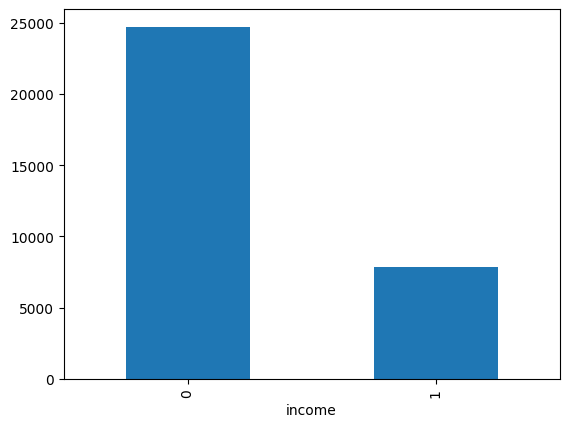

```python
y_transformed.value_counts().plot.bar();
```

Разделим на train и test

```python
X_train, X_test, y_train, y_test = train_test_split(X, y_transformed, test_size=TEST_SIZE, random_state=RANDOM_STATE)
```

```python
X_train.shape, X_test.shape, y_train.shape, y_test.shape
```

```
((26048, 11), (6513, 11), (26048,), (6513,))
```

## Обучение модели

В качестве бейзлайна возьмём логистическую регрессию

```python
model_params = dict(
    penalty='elasticnet', C=1.5, solver='saga', l1_ratio=0.3, max_iter=10000, random_state=RANDOM_STATE
)
model_params
```

```
{'penalty': 'elasticnet',
 'C': 1.5,
 'solver': 'saga',
 'l1_ratio': 0.3,
 'max_iter': 10000,
 'random_state': 42}
```

```python
model = LogisticRegression(**model_params, )
model
```

```
LogisticRegression(C=1.5, l1_ratio=0.3, max_iter=10000, penalty='elasticnet',
                   random_state=42, solver='saga')
```

Соберем пайплайн целиком

```python
pipeline = Pipeline([
    ('preprocess', preprocessor),
    ('model', model)
])
pipeline
```

```
Pipeline(steps=[('preprocess',
                 ColumnTransformer(transformers=[('cat', OneHotEncoder(),
                                                  ['workclass', 'occupation',
                                                   'marital.status', 'sex',
                                                   'native.country', 'race']),
                                                 ('num', StandardScaler(),
                                                  ['education.num',
                                                   'capital.loss',
                                                   'capital.gain', 'age',
                                                   'hours.per.week'])])),
                ('model',
                 LogisticRegression(C=1.5, l1_ratio=0.3, max_iter=10000,
                                    penalty='elasticnet', random_state=42,
                                    solver='saga'))])
```

И запустим обучение

```python
pipeline.fit(X_train, y_train)
pipeline
```

```
Pipeline(steps=[('preprocess',
                 ColumnTransformer(transformers=[('cat', OneHotEncoder(),
                                                  ['workclass', 'occupation',
                                                   'marital.status', 'sex',
                                                   'native.country', 'race']),
                                                 ('num', StandardScaler(),
                                                  ['education.num',
                                                   'capital.loss',
                                                   'capital.gain', 'age',
                                                   'hours.per.week'])])),
                ('model',
                 LogisticRegression(C=1.5, l1_ratio=0.3, max_iter=10000,
                                    penalty='elasticnet', random_state=42,
                                    solver='saga'))])
```

## Оценка качества модели

Получим предсказания на тесте обученной модели

```python
y_proba = pipeline.predict_proba(X_test)[:, 1]
```

```python
y_proba.shape
```

```
(6513,)
```

```python
THRESHOLD = 0.6
```

```python
y_pred = np.where(y_proba >= THRESHOLD, 1, 0)
```

```python
pipeline.steps[0][1].transformers[0][1]
```

```
OneHotEncoder()
```

```python
pipeline.steps[0][1].transformers[1][1]
```

```
StandardScaler()
```

Считаем метрики

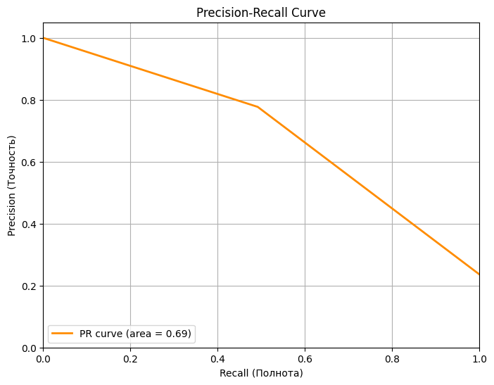

```python
precision, recall, thresholds = precision_recall_curve(y_test, y_pred)
pr_auc = auc(recall, precision)

plt.figure(figsize=(8, 6))
plt.plot(recall, precision, color='darkorange', lw=2, label=f'PR curve (area = {pr_auc:.2f})')

plt.xlim([0.0, 1.0])
plt.ylim([0.0, 1.05])
plt.xlabel('Recall (Полнота)')
plt.ylabel('Precision (Точность)')
plt.title('Precision-Recall Curve')
plt.legend(loc="lower left")
plt.grid(True)

plt.savefig('pr_curve.png', dpi=300, bbox_inches='tight')
plt.show()
```

```python
metrics = {
    'accuracy': accuracy_score(y_test, y_pred),
    'precision': precision_score(y_test, y_pred),
    'recall': recall_score(y_test, y_pred),
    'f1': f1_score(y_test, y_pred),
    'roc_auc': roc_auc_score(y_test, y_proba),
    'pr_auc': pr_auc
}
```

```python
print(f"Accuracy: {metrics['accuracy']:.4f}")
print(f"Precision: {metrics['precision']:.4f}")
print(f"Recall: {metrics['recall']:.4f}")
print(f"F1-score: {metrics['f1']:.4f}")
print(f"ROC-AUC: {metrics['roc_auc']:.7f}")
print(f"PR-AUC: {metrics['pr_auc']:.7f}")
```

```
Accuracy: 0.8468
Precision: 0.7770
Recall: 0.4919
F1-score: 0.6024
ROC-AUC: 0.9013172
PR-AUC: 0.6943799
```

```python
with mlflow.start_run(run_name='logreg_v17'):
    mlflow.log_params(
        {

          'test_size': TEST_SIZE,
          'threshold': THRESHOLD
        }
    )
    mlflow.log_params(model_params)
    mlflow.log_params(
        {
            'cat_features': cat_features,
            'num_features': num_features,
            'cat_preprocessing': type(pipeline.steps[0][1].transformers[0][1]).__name__,
            'num_preprocessing': type(pipeline.steps[0][1].transformers[1][1]).__name__,
        }
    )
    mlflow.log_metrics(metrics)
    mlflow.sklearn.log_model(pipeline, artifact_path='model')
    mlflow.log_artifact('pr_curve.png')
```

```
2026/04/20 13:54:41 WARNING mlflow.models.model: Model logged without a signature and input example. Please set `input_example` parameter when logging the model to auto infer the model signature.
```

```
🏃 View run logreg_v17 at: http://158.160.242.172:5000/#/experiments/12/runs/fe98fa8f474141afa1d59a1860f67e61
🧪 View experiment at: http://158.160.242.172:5000/#/experiments/12
```

# CATBOOST

```python
model_params = {
    'iterations': 10000,
    'learning_rate': 0.01,
    'depth': 7,
    'l2_leaf_reg': 4,
    'random_seed': RANDOM_STATE,
    'verbose': False,
    'early_stopping_rounds': 100,
    'eval_metric': 'AUC'
}

# Создаём модель
model = CatBoostClassifier(**model_params)

# Обучение
model.fit(
    X,
    y,
    cat_features=cat_features,
    verbose=False
)

print("CatBoost успешно обучен с топовыми параметрами!")
```

```
CatBoost успешно обучен с топовыми параметрами!
```

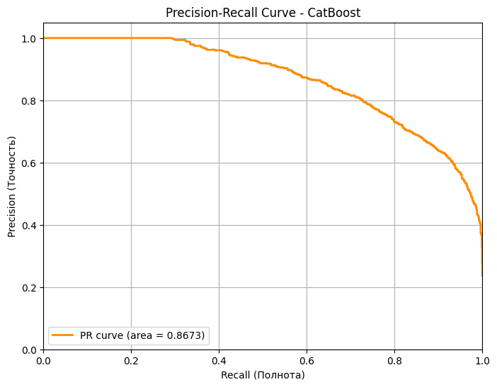

```
Accuracy:  0.8907
Precision: 0.8235
Recall:    0.6831
F1-score:  0.7468
ROC-AUC:   0.9485
PR-AUC:    0.8673
```

```python
# ==================== Предсказания и метрики для CatBoost ====================

# Получаем вероятности положительного класса
y_proba = model.predict_proba(X_test)[:, 1]   # CatBoost возвращает [prob_0, prob_1]

# Бинарные предсказания (по умолчанию порог 0.5)
y_pred = (y_proba >= 0.5).astype(int)

# Расчёт метрик
precision, recall, thresholds = precision_recall_curve(y_test, y_proba)
pr_auc = auc(recall, precision)

# Построение и сохранение PR-кривой
plt.figure(figsize=(8, 6))
plt.plot(recall, precision, color='darkorange', lw=2,
         label=f'PR curve (area = {pr_auc:.4f})')

plt.xlim([0.0, 1.0])
plt.ylim([0.0, 1.05])
plt.xlabel('Recall (Полнота)')
plt.ylabel('Precision (Точность)')
plt.title('Precision-Recall Curve - CatBoost')
plt.legend(loc="lower left")
plt.grid(True)

plt.savefig('pr_curve.png', dpi=300, bbox_inches='tight')
plt.show()

# Метрики
metrics = {
    'accuracy': accuracy_score(y_test, y_pred),
    'precision': precision_score(y_test, y_pred),
    'recall': recall_score(y_test, y_pred),
    'f1': f1_score(y_test, y_pred),
    'roc_auc': roc_auc_score(y_test, y_proba),
    'pr_auc': pr_auc
}

print(f"Accuracy:  {metrics['accuracy']:.4f}")
print(f"Precision: {metrics['precision']:.4f}")
print(f"Recall:    {metrics['recall']:.4f}")
print(f"F1-score:  {metrics['f1']:.4f}")
print(f"ROC-AUC:   {metrics['roc_auc']:.4f}")
print(f"PR-AUC:    {metrics['pr_auc']:.4f}")
```

```python
with mlflow.start_run(run_name='catboost_v4'):
    # Логируем параметры модели
    mlflow.log_params(model_params)

    # Информация о данных и признаках
    mlflow.log_params({
        'num_features': num_features,
        'cat_features': cat_features,
        'model_type': 'CatBoostClassifier',
        'test_size': TEST_SIZE,
        'threshold': 0.5
    })

    # Логируем метрики
    mlflow.log_metrics(metrics)

    # Логируем модель CatBoost
    mlflow.catboost.log_model(model, artifact_path="model")

    # Логируем PR-кривую
    mlflow.log_artifact('pr_curve.png')

    print("✅ CatBoost модель + обновлённая PR-кривая успешно залогированы в MLflow")
```

```
2026/04/20 14:57:36 WARNING mlflow.models.model: Model logged without a signature and input example. Please set `input_example` parameter when logging the model to auto infer the model signature.
```

```
✅ CatBoost модель + обновлённая PR-кривая успешно залогированы в MLflow
🏃 View run catboost_v4 at: http://158.160.242.172:5000/#/experiments/12/runs/ffc78590e0924ddaa7dc54434fda5f6d
🧪 View experiment at: http://158.160.242.172:5000/#/experiments/12
```